# Tooth Growth

jagdeep s sihota

## ToothGrowth: Data Analysis

### 1. Load the ToothGrowth data :

```r
library(datasets)
library(ggplot2)
data(ToothGrowth)
summary(ToothGrowth)
```

```
##       len       supp         dose
##  Min.   : 4.2   OJ:30   Min.   :0.50
##  1st Qu.:13.1   VC:30   1st Qu.:0.50
##  Median :19.2           Median :1.00
##  Mean   :18.8           Mean   :1.17
##  3rd Qu.:25.3           3rd Qu.:2.00
##  Max.   :33.9           Max.   :2.00
```

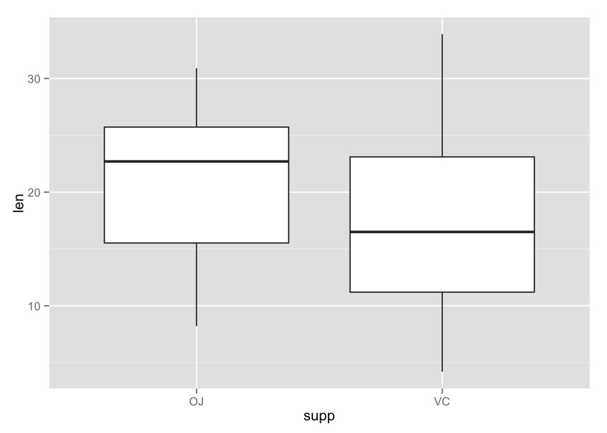

```r
ggplot(ToothGrowth, aes(x=supp, y=len)) + geom_boxplot()
```

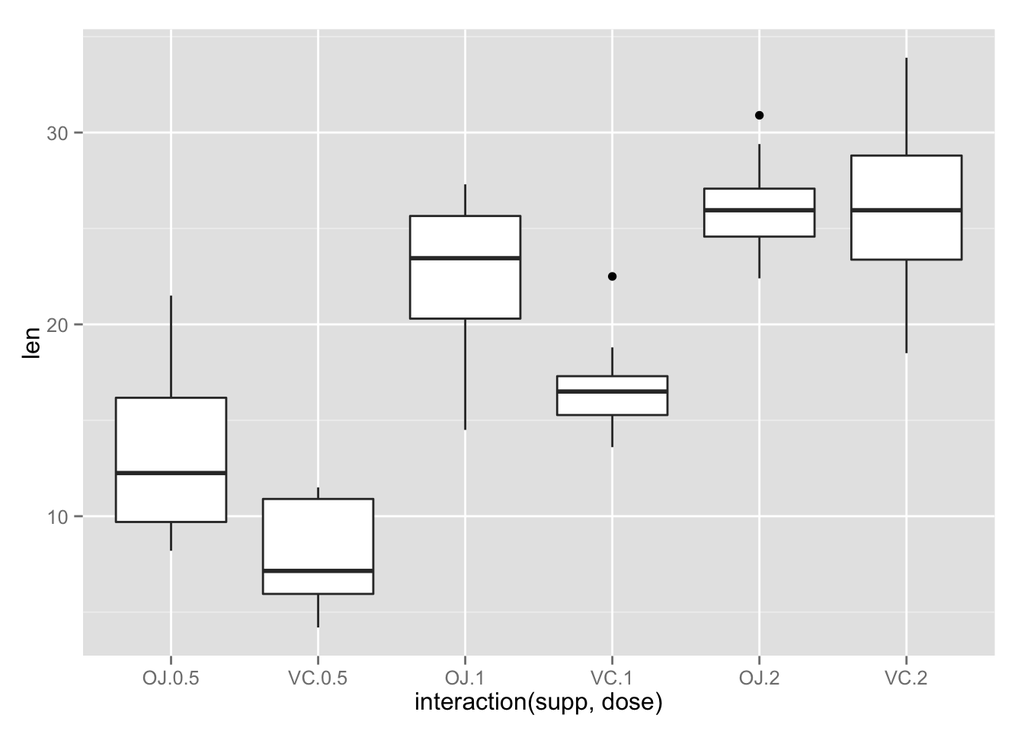

```r
ggplot(ToothGrowth, aes(x=interaction(supp, dose), y=len)) + geom_boxplot()
```

#### Basic summary of the data

Data shows administering larger doses of vitamin C resulted in, on average, longer teeth, but we can’t figure out which method of administering the vitamin is more effective.

### 3. Use confidence intervals and hypothesis tests to compare tooth growth by supp and dose:

#### 3.1. Tooth Growth by Suppliment:

Average increased tooth length for the OJ group versus the VC group:

```r
OJTest <- ToothGrowth[ToothGrowth$supp=="OJ", "len"]
VCTest <- ToothGrowth[ToothGrowth$supp=="VC", "len"]
lengthChange=OJTest - VCTest
```

The group treated with OJ has higher mean length of 20.6633 vs the VC group having the mean of about 16.9633. Is this mean administering OJ makes average tooth growth bigger?

Setting up the null and alternate hypotheses: **Ho:** lengthChange=0 VS. **Ha:** lengthChange>0

```r
lower_bound_ci=mean(lengthChange) - 1.96*sd(lengthChange)/sqrt(length(lengthChange))
upper_bound_ci=mean(lengthChange) + 1.96*sd(lengthChange)/sqrt(length(lengthChange))
```

We reject the null hypothesis becasue the confidence interval (1.5041,5.8959) does not include 0 - the mean length change for null hypothesis

#### 3.2. Tooth Growth by Dose:

##### Tooth Growth by Suppliment when dosage is (0.5,1):

```r
lowOJ <- ToothGrowth[ToothGrowth$supp=="OJ" & ToothGrowth$dose %in% c(0.5,1),"len"]
lowVC <- ToothGrowth[ToothGrowth$supp=="VC" & ToothGrowth$dose %in% c(0.5,1),"len"]
```

Confidence interval and test the hypothesis:

```r
alpha<-0.05;
th<-t.test(lowOJ,lowVC);
```

For t>0, confidence interval limits >0, **Ho:**meanOfOJ = meanOfVC VS. **Ha**: meanOfOJ > meanOfVC

Ho is rejected, because TS(t = 3.0503) > qt(1-alpha,36.5531)( = 1.6876).

##### Tooth Growth by Suppliment when dosage is 2:

```r
highOJ<- ToothGrowth[ToothGrowth$supp=="OJ" & ToothGrowth$dose==2,"len"]
highVC<- ToothGrowth[ToothGrowth$supp=="VC" & ToothGrowth$dose==2,"len"]
th<-t.test(highOJ,highVC);
```

t<0, test the hypothes: **Ho:**meanOfOJ = meanOfVC versus **Ha:** meanOfOJ < meanOfVC

### 4. State your conclusions and the assumptions needed for your conclusions:

#### Assumptions:

- the hypothesis is: both supp have the same impact on tooth length.
- the alternative hypothesis is: OJ can promote the growth of toothlength than VC.
- significance level: 0.05

#### Conclusions:

- OJ have more impact on the growth of toothlength under dose equals to 0.5 or 1.But can’t get this conclusion when dose equals to 2.